# Workshop 6: What Regression Is For

FEV lung function, age, height, and smoking

YOUR NAME HERE

2026-06-25

# Introduction

In this workshop you will use simple linear regression to study lung function in children and adolescents.

The dataset contains 654 youths aged 3 to 19 from East Boston in the 1970s. The original teaching purpose of this dataset was to study smoking and lung function. The outcome is **forced expiratory volume** (`fev_l`), measured in litres. FEV measures how much air a person can forcefully breathe out in one second. Higher values mean better lung function.

Using this dataset, the workshop will demonstrate the three main uses of regression:

1. **Part 1: Describe** a relationship between variables.
2. **Part 2: Predict** the outcome for a new value of the predictor.
3. **Part 3: Control** for another variable, to (try to) isolate the independent effect of the predictor of interest.

# Load packages and data

```r
if (!require(pacman)) install.packages("pacman")
pacman::p_load(tidyverse, here)
```

```r
fev <- read_csv(here("data/fev_kahn.csv"))
glimpse(fev)
```

```
## Rows: 654
## Columns: 5
## $ age_yrs   <dbl> 9, 8, 7, 9, 9, 8, 6, 6, 8, 9, 6, 8, 8, 8, 8, 7, 5, 6, 9, 9, …
## $ fev_l     <dbl> 1.708, 1.724, 1.720, 1.558, 1.895, 2.336, 1.919, 1.415, 1.98…
## $ height_in <dbl> 57.0, 67.5, 54.5, 53.0, 57.0, 61.0, 58.0, 56.0, 58.5, 60.0, …
## $ sex       <chr> "female", "female", "female", "male", "male", "female", "fem…
## $ smoke     <chr> "non_smoker", "non_smoker", "non_smoker", "non_smoker", "non…
```

**Checkpoint:** `fev` should have **654 rows and 5 columns**.

The variables we will use are:

- `fev_l`: forced expiratory volume in litres
- `age_yrs`: age in years
- `height_in`: height in inches
- `smoke`: current smoking status, `non_smoker` or `smoker`

# Part 1: Describing relationships

The first use of regression is description. We often want to describe how two variables move together.

For two continuous variables, one starting point is a scatterplot and a correlation. Let’s implement this, then we will see how it compares with regression.

## Part 1a: Age and FEV, worked example

In this section, we will look at the relationship between age and FEV.

The code for this section is filled in as a demo. Run the code and focus on reading the output.

### Scatterplot

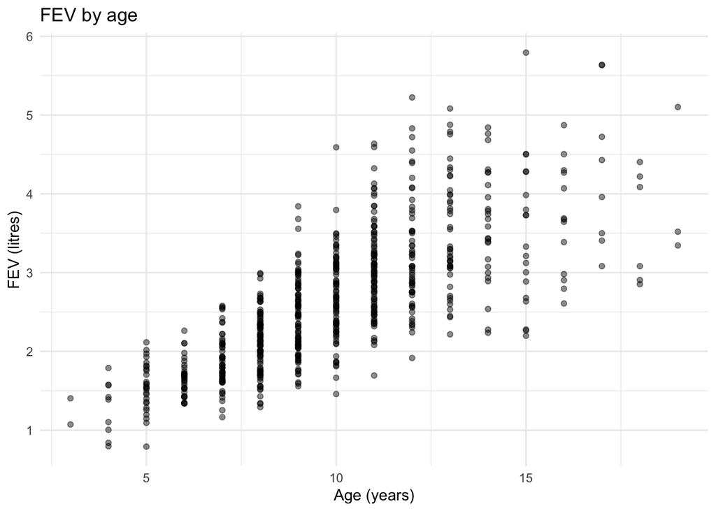

```r
ggplot(fev, aes(x = age_yrs, y = fev_l)) +
  geom_point(alpha = 0.45) +
  labs(
    title = "FEV by age",
    x = "Age (years)",
    y = "FEV (litres)"
  ) +
  theme_minimal()
```

**Question:** Is the relationship between age and FEV positive, negative, or close to zero?

Ans:

### Correlation

Correlation summarizes the direction and strength of a linear relationship. It is always between -1 and +1.

Let’s calculate the correlation between age and FEV.

```r
r_age_fev <- cor(fev$age_yrs, fev$fev_l)
r_age_fev
```

```
## [1] 0.756459
```

The correlation is about **0.756**, a strong positive relationship.

Correlation describes the strength of the relationship, but regression will give us at least three additional abilities: - a p-value that we can use to test whether the association is statistically significant - a prediction equation that we can use to predict lung function for someone whose age we know - the ability to control for another variable, to isolate the independent effect of the predictor of interest

We’ll touch on each of these in the next parts of the workshop.

### Linear regression

Regression gives us a fitted line:

predicted y = intercept + slope * x

where y is the outcome (in this case, FEV) and x is the predictor (in this case, age).

Below, we fit a linear regression model for the age and FEV relationship. The outcome is `fev_l` and the predictor is `age_yrs`.

```r
age_model <- lm(fev_l ~ age_yrs, data = fev)
summary(age_model)
```

```
##
## Call:
## lm(formula = fev_l ~ age_yrs, data = fev)
##
## Residuals:
##      Min       1Q   Median       3Q      Max
## -1.57539 -0.34567 -0.04989  0.32124  2.12786
##
## Coefficients:
##             Estimate Std. Error t value Pr(>|t|)
## (Intercept) 0.431648   0.077895   5.541 4.36e-08 ***
## age_yrs     0.222041   0.007518  29.533  < 2e-16 ***
## ---
## Signif. codes:  0 '***' 0.001 '**' 0.01 '*' 0.05 '.' 0.1 ' ' 1
##
## Residual standard error: 0.5675 on 652 degrees of freedom
## Multiple R-squared:  0.5722, Adjusted R-squared:  0.5716
## F-statistic: 872.2 on 1 and 652 DF,  p-value: < 2.2e-16
```

The `Estimate` column gives the intercept and slope.

**Question:** Fill in the blanks.

The fitted equation is

predicted FEV = ______ + ______ * age

The slope means: For each additional 1 year of age, predicted FEV is higher by about _______ litres, on average.

The p-value tests the null hypothesis that the true slope is 0. Here the p-value is far below 0.05, so there is ______ (strong / weak) evidence that age and FEV have a nonzero linear association.

### Drawing the fitted line

We can extract the intercept and slope and draw the fitted line ourselves.

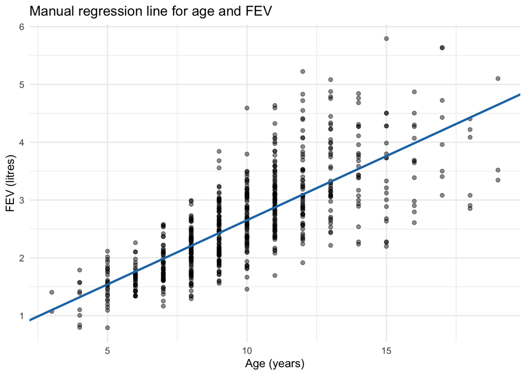

```r
age_intercept <- coef(age_model)[1]
age_slope <- coef(age_model)[2]

ggplot(fev, aes(x = age_yrs, y = fev_l)) +
  geom_point(alpha = 0.45) +
  geom_abline(
    intercept = age_intercept,
    slope = age_slope,
    color = "#1f78b4",
    linewidth = 1
  ) +
  labs(
    title = "Manual regression line for age and FEV",
    x = "Age (years)",
    y = "FEV (litres)"
  ) +
  theme_minimal()
```

In practice, we usually let `geom_smooth()` do this.

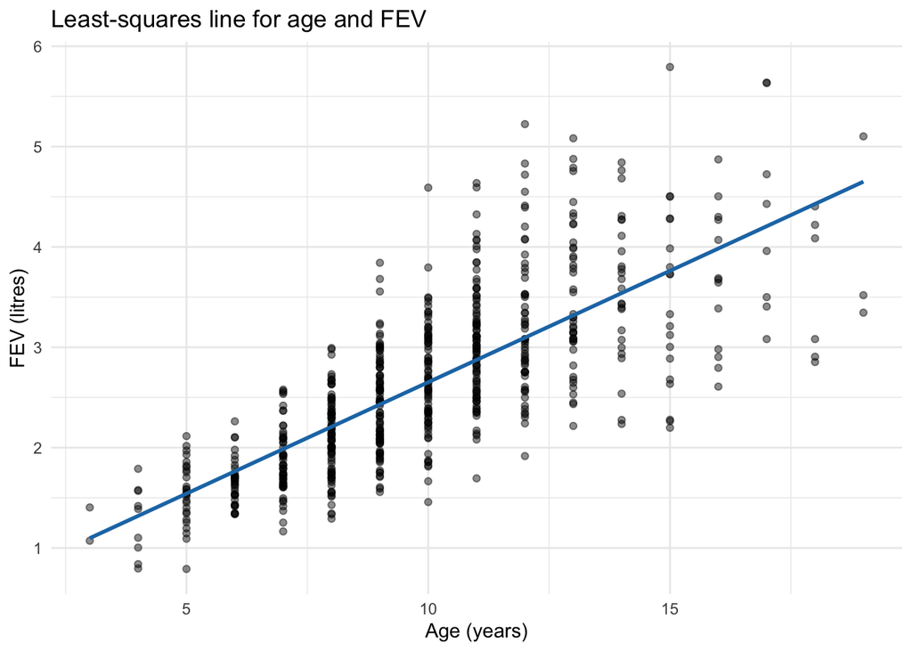

```r
ggplot(fev, aes(x = age_yrs, y = fev_l)) +
  geom_point(alpha = 0.45) +
  geom_smooth(method = "lm", se = FALSE, color = "#1f78b4") +
  labs(
    title = "Least-squares line for age and FEV",
    x = "Age (years)",
    y = "FEV (litres)"
  ) +
  theme_minimal()
```

### R-squared

At the bottom of `summary(age_model)`, you will see the model’s R-squared.

```r
summary(age_model)$r.squared
```

```
## [1] 0.5722302
```

The R-squared is about **0.572**.

This R-squared means that about 57.2% of the variation in FEV is explained by age in this simple linear regression.

Interestingly, in simple linear regression with one predictor, R-squared is equal to the correlation squared:

```r
r_age_fev^2
```

```
## [1] 0.5722302
```

## Part 1b: Height and FEV, your turn

Age predicts FEV fairly well, but height is usually closer to lung size than age is.

In this section, it is your turn to repeat the same steps for height, using the same syntax as Part 1a.

### Scatterplot

Make a scatterplot with height on the x-axis and FEV on the y-axis.

```r
# YOUR CODE HERE
```

**Question:** Does the relationship look positive, negative, or close to zero?

Ans:

### Correlation

Calculate the correlation between height and FEV.

```r
r_height_fev <- cor(__________, __________)
r_height_fev
```

**Question:** Fill in the blanks.

The correlation is about ______. This relationship is ______ (positive / negative) and ______ (weak / moderate / strong).

Ans:

### Linear regression

Fit a simple linear regression with `fev_l` as the outcome and `height_in` as the predictor.

```r
height_model <- lm(__________ ~ __________, data = fev)
summary(height_model)
```

**Question:** Fill in the fitted equation.

predicted FEV = ______ + ______ * height

Ans:

**Question:** The height slope is about **0.132**. Interpret this slope in one sentence.

Ans:

**Question:** What is the p-value for `height_in`? At alpha = 0.05, do we reject or fail to reject the null hypothesis that the true slope is 0?

Ans:

### R-squared

Extract the R-squared from the model summary.

```r
summary(__________)$r.squared
```

**Question:** The height model has R-squared about **0.754**. Fill in the blanks.

About ______% of the variation in FEV is explained by ______ in this simple linear regression.

Ans:

## Part 1c: Comparing the age and height models

Use your results from Parts 1a and 1b.

- Age model R-squared: about 0.572
- Height model R-squared: about 0.754

**Question:** Which predictor gives the better one-variable model for FEV, age or height? How do you know?

Ans:

# Part 2: Predicting with regression

Another use of regression is prediction. Once we have a fitted equation, we can plug in a new value of the predictor and get a predicted outcome.

First, here is a fully worked prediction using the age model.

```r
new_age <- tibble(age_yrs = 12)
new_age
```

```
## # A tibble: 1 × 1
##   age_yrs
##     <dbl>
## 1      12
```

```r
predict(age_model, newdata = new_age)
```

```
##       1
## 3.09614
```

The model predicts that a 12-year-old has FEV about **3.10 litres**, on average.

Now use the height model to predict FEV for a 60-inch-tall youth.

```r
new_height <- tibble(height_in = _______)
predict(__________, newdata = __________)
```

**Question:** What is the predicted FEV for a youth who is 60 inches tall?

Ans:

Finally, use the height model to predict FEV for a 20-inch-tall baby.

```r
baby_height <- tibble(height_in = _______)
predict(__________, newdata = __________)
```

**Question:** What prediction does the model give for a 20-inch-tall baby? Does that prediction make sense? What does this teach us about using regression models outside the observed data range?

Ans:

# Part 3: Controlling for another variable

This final part covers the third use of regression: to **control** for another variable, in order to isolate the independent effect of the predictor of interest. This is also known as multiple regression.

The goal of this part is to see why multiple regression is useful.

Below, we will work through the following parts:

- **Part 3a:** Summarise age, height, and FEV by smoking status.
- **Part 3b:** Fit a raw smoking model.
- **Part 3c:** Control for age and height in a preview of multiple regression.

## Part 3a: Summarise by smoking status

The original dataset documentation says `smoke` records current smoking status for the participants. (You may be surprised to see that many children and teenagers in the dataset were smokers! These are children and teenagers from the 1970s, when youth smoking was more common than it is now.)

Let’s now ask a public-health question using regression:

> Is smoking associated with lung function?

To do this, we can create a summary to see the mean age, height and FEV for each smoking status.

```r
fev %>%
  group_by(smoke) %>%
  summarise(
    n = n(),
    mean_age = mean(age_yrs),
    mean_height = mean(height_in),
    mean_fev = mean(fev_l),
    .groups = "drop"
  )
```

```
## # A tibble: 2 × 5
##   smoke          n mean_age mean_height mean_fev
##   <chr>      <int>    <dbl>       <dbl>    <dbl>
## 1 non_smoker   589     9.53        60.6     2.57
## 2 smoker        65    13.5         66.0     3.28
```

**Question:** Which group has higher mean FEV, smokers or non-smokers?

Ans:

**Question:** Which group is older on average? Which group is taller on average?

Ans:

The raw results may seem surprising. Smokers have higher mean FEV, which one might interpret to mean that smoking improves lung function. However, smokers are also much older and taller on average. Older and taller youths naturally have larger lungs.

Thus we might need to control for age and height to isolate the independent effect of smoking on lung function.

## Part 3b: Raw smoking model

First let’s fit a simple linear regression model to see the effect of smoking on lung function, without controlling for age or height.

```r
raw_model <- lm(fev_l ~ smoke, data = fev)
summary(raw_model)
```

```
##
## Call:
## lm(formula = fev_l ~ smoke, data = fev)
##
## Residuals:
##     Min      1Q  Median      3Q     Max
## -1.7751 -0.6339 -0.1021  0.4804  3.2269
##
## Coefficients:
##             Estimate Std. Error t value Pr(>|t|)
## (Intercept)  2.56614    0.03466  74.037  < 2e-16 ***
## smokesmoker  0.71072    0.10994   6.464 1.99e-10 ***
## ---
## Signif. codes:  0 '***' 0.001 '**' 0.01 '*' 0.05 '.' 0.1 ' ' 1
##
## Residual standard error: 0.8412 on 652 degrees of freedom
## Multiple R-squared:  0.06023,    Adjusted R-squared:  0.05879
## F-statistic: 41.79 on 1 and 652 DF,  p-value: 1.993e-10
```

The row labeled `smokesmoker` compares smokers with the reference group, non-smokers. In the raw model, the smoking coefficient is about **0.711**. This is the difference in mean FEV between smokers and non-smokers.

That does **not** mean smoking improves lung function. This is observational data, and smoking is tangled up with age and height.

## Part 3c: Controlling for age and height

Now here is the multiple regression model that controls for age and height. We simply add age and height to the model.

```r
controlled_model <- lm(fev_l ~ smoke + age_yrs + height_in, data = fev)
summary(controlled_model)
```

```
##
## Call:
## lm(formula = fev_l ~ smoke + age_yrs + height_in, data = fev)
##
## Residuals:
##      Min       1Q   Median       3Q      Max
## -1.50182 -0.26305 -0.01882  0.24989  1.98535
##
## Coefficients:
##              Estimate Std. Error t value Pr(>|t|)
## (Intercept) -4.616007   0.223883 -20.618  < 2e-16 ***
## smokesmoker -0.110232   0.060017  -1.837   0.0667 .
## age_yrs      0.059741   0.009563   6.247 7.57e-10 ***
## height_in    0.109095   0.004720  23.115  < 2e-16 ***
## ---
## Signif. codes:  0 '***' 0.001 '**' 0.01 '*' 0.05 '.' 0.1 ' ' 1
##
## Residual standard error: 0.4189 on 650 degrees of freedom
## Multiple R-squared:  0.7676, Adjusted R-squared:  0.7665
## F-statistic: 715.7 on 3 and 650 DF,  p-value: < 2.2e-16
```

Now the row labeled `smokesmoker` has a coefficient of about **-0.110**, and its p-value is about **0.067**. After controlling for age and height, this model does not give strong evidence that smokers and non-smokers have different predicted FEV.

**Question:** In one or two sentences, explain why the raw smoking comparison was misleading.

Ans:

# Wrap-up

In this workshop, regression helped us do three things:

1. **Part 1: Describe (1a, 1b, and 1c):** age and height both have positive linear relationships with FEV, and height gives the better one-variable model.
2. **Part 2: Predict:** the height model can predict FEV for a new height value, but predictions outside the observed data range can become nonsensical.
3. **Part 3: Control (3a, 3b, and 3c):** the smoking example showed why an observational association can change after accounting for other variables.

You will learn multiple regression properly in coming lessons. For now, the key idea is that regression is not just a line on a plot. It is a way to ask clearer questions about relationships in data.